# Decorrelation-Based Feature Discovery: Personality Clustering

Jose Tamez

2024-01-05

# 1 Effect of UPSTM-Based Decorrelation on Feature Discovery

## 1.1 Loading the libraries

```r
library("FRESA.CAD")
library(readxl)
library(igraph)
library(umap)
library(tsne)
library(entropy)

op <- par(no.readonly = TRUE)
pander::panderOptions('digits', 3)
pander::panderOptions('table.split.table', 400)
pander::panderOptions('keep.trailing.zeros',TRUE)
```

## 1.2 Material

Data Source https://quantdev.ssri.psu.edu/tutorials/intro-basic-exploratory-factor-analysis

“For this example, we use data from the web that are collected and distributed at https://openpsychometrics.org/_rawdata/. The data were obtained from 19,719 participants (rows) who provided answers to the Big Five Personality Test, constructed with items from the International Personality Item Pool. Data columns include gender, age, race, native language, country, and answers to the 50 likert rated statements (1-5;0 if missed; 1 was labeled as “strongly disagree”, 2 was labeled as “disagree”, 3 was labeled as “neither agree not disagree”, 4 was labeled as “agree” and 5 was labeled as “strongly agree”.) The original files can be obtaned at http://openpsychometrics.org/_rawdata/BIG5.zip”

## 1.3 The Data

```r
BigData <- as.data.frame(read_excel("~/GitHub/LatentBiomarkers/Data/BigData.xlsx"))

BigData[BigData==0] <- NA
BigData <- BigData[complete.cases(BigData),]
BigData <- BigData[BigData$age<100,]

BigData <- BigData[,-c(1,3,5,6,7)]

BigData$gender <- 1*(BigData$gender==1)


BigData$age <- log10(BigData$age)
```

### 1.3.1 Standarize the names for the reporting

```r
studyName <- "PersonalityAge"

thro <- 0.2
cexheat <- 0.15
dataframe_FDe <- ILAA(BigData,thr=thro,verbose=TRUE,bootstrap=30)
```

fast | LM | N8 age E1 E2 E3 E4 E5 0.03921569 0.74509804 0.68627451 0.76470588 0.50980392 0.92156863

Included: 51 , Uni p: 0.002941176 , Base Size: 1 , Rcrit: 0.01982345

1 <R=0.518,thr=0.700>, Top: 1< 1 >Fa= 1,<|><>Tot Used: 2 , Added: 1 , Zero Std: 0 , Max Cor: 0.649

2 <R=0.506,thr=0.600>, Top: 5< 1 >Fa= 6,<|><>Tot Used: 12 , Added: 5 , Zero Std: 0 , Max Cor: 0.590

3 <R=0.463,thr=0.500>, Top: 8< 4 >Fa= 11,<|><>Tot Used: 29 , Added: 13 , Zero Std: 0 , Max Cor: 0.555

4 <R=0.369,thr=0.500>, Top: 1< 1 >Fa= 12,<|><>Tot Used: 31 , Added: 1 , Zero Std: 0 , Max Cor: 0.480

5 <R=0.361,thr=0.400>, Top: 4< 2 >Fa= 13,<|><>Tot Used: 36 , Added: 6 , Zero Std: 0 , Max Cor: 0.421

6 <R=0.337,thr=0.400>, Top: 2< 1 >Fa= 15,<|><>Tot Used: 36 , Added: 2 , Zero Std: 0 , Max Cor: 0.398

7 <R=0.327,thr=0.300>, Top: 13< 1 >Fa= 17,<|><>Tot Used: 49 , Added: 21 , Zero Std: 0 , Max Cor: 0.347

8 <R=0.278,thr=0.300>, Top: 6< 1 >Fa= 18,<|><>Tot Used: 49 , Added: 6 , Zero Std: 0 , Max Cor: 0.299

9 <R=0.256,thr=0.200>, Top: 12< 3 >Fa= 19,<|><>Tot Used: 49 , Added: 18 , Zero Std: 0 , Max Cor: 0.293

10 <R=0.245,thr=0.200>, Top: 4< 4 >Fa= 20,<|><>Tot Used: 50 , Added: 7 , Zero Std: 0 , Max Cor: 0.254

11 <R=0.241,thr=0.200>, Top: 4< 1 >Fa= 21,<|><>Tot Used: 50 , Added: 2 , Zero Std: 0 , Max Cor: 0.200

12 <R=0.200,thr=0.200>

[ 12 ], 0.1991727 Decor Dimension: 50 Nused: 50 . Cor to Base: 39 , ABase: 51 , Outcome Base: 0

gender O9 E5 N8 A4 C2 1 1 1 1 1 1

```r
dataframe <- as.data.frame(t(scale(dataframe_FDe[sample(nrow(dataframe_FDe),1000),])))
colnames(dataframe) <- paste("S",colnames(dataframe),sep="")
```

### 1.3.2 Decorrelating using ILAA

ILAA bootstrapped training and testing sets

```r
dataframe_De <- ILAA(dataframe,thr=0.25,verbose=TRUE,bootstrap=30)
```

fast | LM | S13104 S9467 S7675 S17102 S8167 S14593 S11419 S6271 S17974 S7370 S6790 S18570 0.635 0.639 0.747 0.947 0.533 0.150

Included: 1000 , Uni p: 0.00015 , Base Size: 594 , Rcrit: 0.4816724

1 <R=0.531,thr=0.700>, Top: 3< 1 >Fa= 3,<|><>Tot Used: 6 , Added: 3 , Zero Std: 0 , Max Cor: 0.696

2 <R=0.530,thr=0.600>, Top: 14< 2 >Fa= 15,<|><>Tot Used: 35 , Added: 17 , Zero Std: 0 , Max Cor: 0.647

3 <R=0.524,thr=0.600>, Top: 1< 2 >Fa= 16,<|><>Tot Used: 38 , Added: 2 , Zero Std: 0 , Max Cor: 0.599

4 <R=0.523,thr=0.500>, Top: 142< 3 >.Fa= 140,<|><>Tot Used: 323 , Added: 168 , Zero Std: 0 , Max Cor: 0.594

5 <R=0.502,thr=0.500>, Top: 45< 1 >Fa= 168,<|><>Tot Used: 366 , Added: 40 , Zero Std: 0 , Max Cor: 0.647

6 <R=0.495,thr=0.600>, Top: 1< 1 >Fa= 169,<|><>Tot Used: 366 , Added: 1 , Zero Std: 0 , Max Cor: 0.544

7 <R=0.494,thr=0.500>, Top: 20< 1 >Fa= 175,<|><>Tot Used: 374 , Added: 8 , Zero Std: 0 , Max Cor: 0.514

8 <R=0.492,thr=0.500>, Top: 15< 1 >Fa= 177,<|><>Tot Used: 374 , Added: 3 , Zero Std: 0 , Max Cor: 0.502

9 <R=0.491,thr=0.500>, Top: 12< 1 >Fa= 177,<><>Tot Used: 374 , Added: 0 , Zero Std: 0 , Max Cor: 0.502

12 <R=0.491,thr=0.482>, Top: 103< 1 >Fa= 177,<><>Tot Used: 374 , Added: 0 , Zero Std: 0 , Max Cor: 0.502

[ 12 ], 0.4987316 Decor Dimension: 374 Nused: 374 . Cor to Base: 217 , ABase: 1000 , Outcome Base: 0

S6271 S18570 S7570 S16550 S7841 S6163 1 1 1 1 1 1

The heat map of the data

```r
par(op)


  par(cex=0.6,cex.main=0.85,cex.axis=0.7)
  cormat <- cor(dataframe,method="pearson")
  cormat[is.na(cormat)] <- 0
  gplots::heatmap.2(abs(cormat),
                    trace = "none",
  #                  scale = "row",
                    mar = c(5,5),
                    col=rev(heat.colors(5)),
                    main = "Subject Correlation",
                    cexRow = cexheat,
                    cexCol = cexheat,
                     srtCol=45,
                     srtRow=45,
                    key.title=NA,
                    key.xlab="|Pearson Correlation|",
                    xlab="Subject", ylab="Subject")
  diag(cormat) <- 0
  pander::pander(max(abs(cormat)))
```

*0.716*

[figure not shown]

```r
par(op)
```

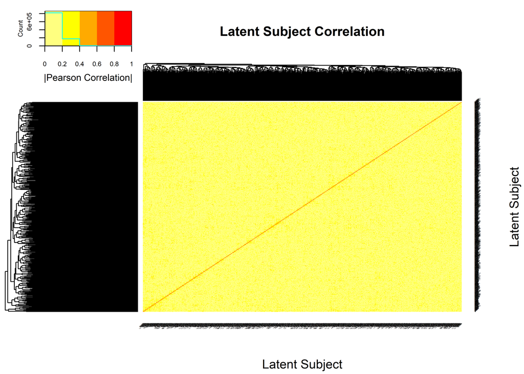

```r
  par(cex=0.6,cex.main=0.85,cex.axis=0.7)
  cormat <- cor(dataframe_De,method="pearson")
  cormat[is.na(cormat)] <- 0
  gplots::heatmap.2(abs(cormat),
                    trace = "none",
  #                  scale = "row",
                    mar = c(5,5),
                    col=rev(heat.colors(5)),
                    main = "Latent Subject Correlation",
                    cexRow = cexheat,
                    cexCol = cexheat,
                     srtCol=45,
                     srtRow=45,
                    key.title=NA,
                    key.xlab="|Pearson Correlation|",
                    xlab="Latent Subject", ylab="Latent Subject")
```

```r
  diag(cormat) <- 0
  pander::pander(max(abs(cormat)))
```

*0.515*

```r
par(op)
```

### 1.3.3 Formulas Network

Displaying the features associations

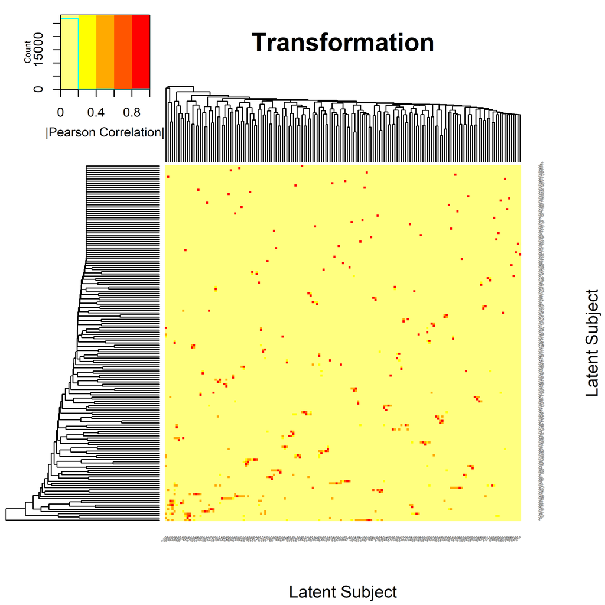

```r
par(op)

  transform <- 1*(attr(dataframe_De,"UPLTM") != 0)
  colnames(transform) <- str_remove_all(colnames(transform),"La_")
  srow <- apply(transform,1,sum) > 5
  rtans <- transform[srow,]
  scol <- apply(rtans,2,sum) > 1*(colnames(rtans) %in% rownames(rtans))
  rtans <- rtans[,scol]
  strans <- unique(c(rownames(rtans),colnames(rtans)))
  transform <- transform[strans,strans]

  transform <- abs(transform*cor(dataframe[,rownames(transform)])) # The weights are proportional to the observed correlation


    gplots::heatmap.2(as.matrix(transform),
                    trace = "none",
  #                  scale = "row",
                    mar = c(5,5),
                    col=rev(heat.colors(5)),
                    main = "Transformation",
                    cexRow = cexheat,
                    cexCol = cexheat,
                     srtCol=45,
                     srtRow=45,
                    key.title=NA,
                    key.xlab="|Pearson Correlation|",
                    xlab="Latent Subject", ylab="Latent Subject")

par(op)
```

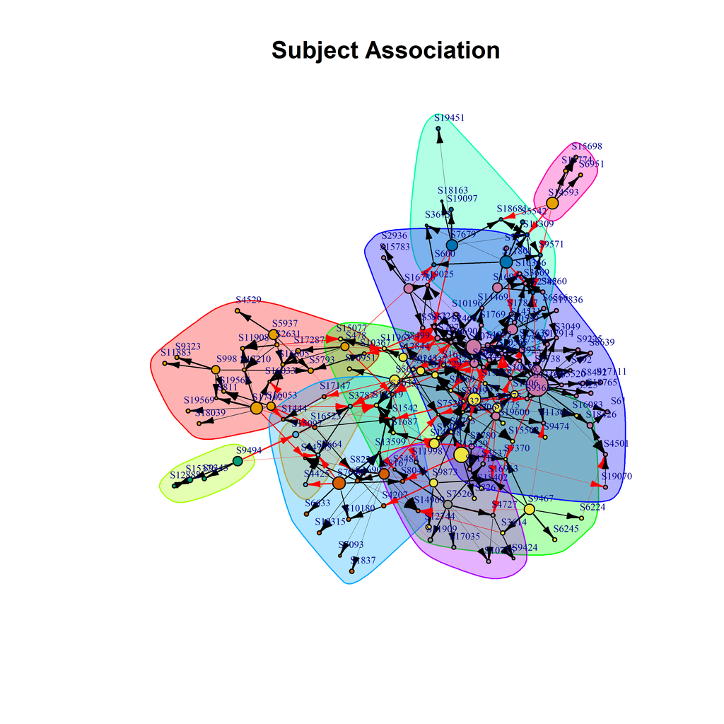

```r
  VertexSize <- attr(dataframe_De,"fscore") # The size depends on the variable independence relevance (fscore)
  names(VertexSize) <- str_remove_all(names(VertexSize),"La_")
  VertexSize <- 0.5 + 9.5*(VertexSize-min(VertexSize))/(max(VertexSize)-min(VertexSize)) # Normalization
  VertexSize <- VertexSize[colnames(transform)]
  gr <- graph_from_adjacency_matrix(transform,mode = "directed",diag = FALSE,weighted=TRUE)
  gr$layout <- layout_with_fr

#  fc <- cluster_optimal(gr)
#  fc <- cluster_spinglass(gr,spins = 50)
#  fc <- cluster_edge_betweenness(gr)
#  fc <- cluster_leading_eigen(gr)
  fc <- cluster_walktrap (gr,steps = 50)
  plot(fc, gr,
       edge.width = 2*E(gr)$weight,
       vertex.size=VertexSize,
       edge.arrow.size=0.5,
       edge.arrow.width=0.75,
       vertex.label.cex=0.5,
       vertex.label.dist=1,
       main="Subject Association")
```

```r
par(op)

      varratios <- attr(dataframe_De,"VarRatio")
      names(varratios) <- str_remove_all(names(varratios),"La_")
      fscores <- attr(dataframe_De,"fscore")
      names(fscores) <- str_remove_all(names(fscores),"La_")
      clustable <- as.data.frame(cbind(Variable=fc$names,
                                       Cluster=fc$membership,
                                       ResidualVariance=round(varratios[fc$names],3),
                                       Fscore=round(fscores[fc$names],3),
                                       VertexSize=round(VertexSize[fc$names],3)
                                       )
                                 )
      rownames(clustable) <- str_replace_all(rownames(clustable),"__","_")
      clustable$Variable <- NULL
      clustable$Cluster <- as.integer(clustable$Cluster)
      clustable$ResidualVariance <- as.numeric(clustable$ResidualVariance)
      clustable$Fscore <- as.numeric(clustable$Fscore)
      clustable <- clustable[order(-clustable$ResidualVariance),]
      clustable <- clustable[order(clustable$Cluster),]

pander::pander(as.matrix(clustable))
```

|  | Cluster | ResidualVariance | Fscore | VertexSize |
| --- | --- | --- | --- | --- |
| **S16053** | 1 | 1.000 | 1.247 | 3.904 |
| **S5937** | 1 | 1.000 | 2.077 | 4.626 |
| **S478** | 1 | 1.000 | 1.134 | 3.806 |
| **S17102** | 1 | 1.000 | 3.115 | 5.531 |
| **S998** | 1 | 1.000 | 1.253 | 3.909 |
| **S19569** | 1 | 0.727 | -1.000 | 1.948 |
| **S11908** | 1 | 0.717 | -1.022 | 1.928 |
| **S11883** | 1 | 0.703 | -1.051 | 1.903 |
| **S4529** | 1 | 0.691 | -0.813 | 2.11 |
| **S5793** | 1 | 0.686 | -0.297 | 2.559 |
| **S16805** | 1 | 0.685 | -1.076 | 1.881 |
| **S19565** | 1 | 0.653 | -1.082 | 1.876 |
| **S18039** | 1 | 0.649 | -1.152 | 1.815 |
| **S9323** | 1 | 0.641 | -1.000 | 1.948 |
| **S2631** | 1 | 0.630 | -0.962 | 1.981 |
| **S17287** | 1 | 0.602 | -0.669 | 2.236 |
| **S10367** | 1 | 0.575 | -1.297 | 1.689 |
| **S16033** | 1 | 0.509 | -1.689 | 1.348 |
| **S17210** | 1 | 0.507 | -1.141 | 1.825 |
| **S811** | 1 | 0.377 | -1.580 | 1.443 |
| **S15097** | 2 | 0.739 | 0.029 | 2.844 |
| **S4425** | 2 | 0.683 | -1.065 | 1.891 |
| **S7664** | 2 | 0.636 | -1.095 | 1.865 |
| **S3787** | 2 | 0.577 | -1.060 | 1.895 |
| **S9494** | 3 | 1.000 | 1.805 | 4.39 |
| **S12888** | 3 | 0.714 | -1.062 | 1.894 |
| **S15376** | 3 | 0.690 | -0.217 | 2.629 |
| **S9343** | 3 | 0.627 | -0.961 | 1.981 |
| **S1337** | 4 | 1.000 | 3.803 | 6.129 |
| **S13829** | 4 | 1.000 | 4.747 | 6.952 |

[output cut: 135 more lines]